# Bryce McGowens Flourishing Freshman Season

Kaden Ross

2022-04-06

The hype surrounding Bryce McGowens was nothing short of extraordinary because everyone knows how us Nebraska fans are.

McGowens is the only five star recruit Nebraska has ever had in the history of their basketball program.

Even though Nebraska’s season did not go so well, he proved what made him a five star recruit with his natural scoring ability coming right out high school.

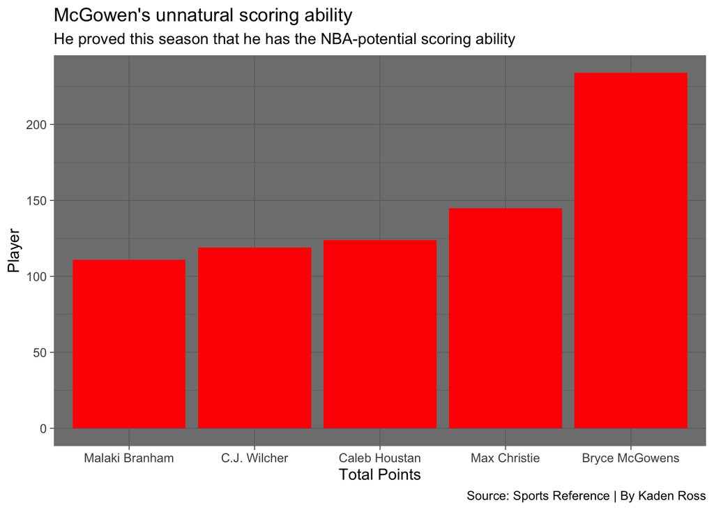

Nebraska’s Mcgowens led all the Big Ten freshman in scoring and somehow he was not awarded Big Ten Freshman of the Year. Weird huh?

We all know Nebraska is not the best basketball school, but that should not take away from the fact McGowens lead all the freshman in scoring while playing in arguably the best conference in college basketball.

Getting valuable playing time in a power five conference is not easy, especially for an incoming freshman. Looking at minutes played, we can see how often Bryce was on the court for the whole season.

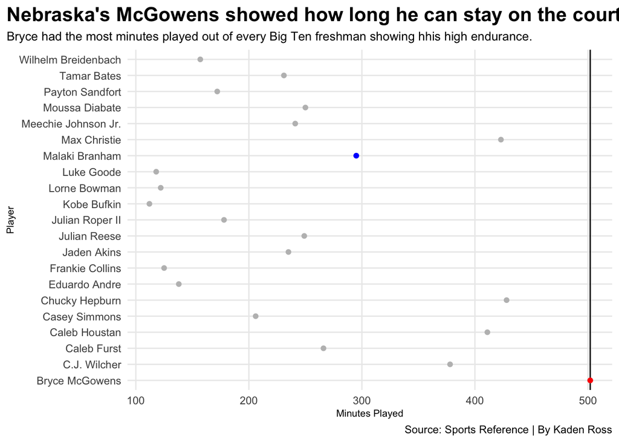

Having a high number of minutes played shows how valuable a player was for their team, and ultimately shows how good that player is.

Malaki Branham won the Big Ten Freshman of the Year award when he wasn’t on the court as much as Bryce, and did not even come close to his total points scored.

Something doesn’t add up here, right?

The worst thing a player can do in basketball is turn the ball over. Let’s look at how often Bryce Bryce committed a turnover compared to Malaki Branham.

How trustworthy is McGowens on the court?

Notice a five percent difference is a significant amount in basketball.

| Player | Turnover Percentage | Turnovers | Games Played |
| --- | --- | --- | --- |
| Bryce McGowens | 11.5 | 30 | 15 |
| Malaki Branham | 16.7 | 21 | 12 |

**By:** Kaden Ross | **Source:** Sports Reference

The turnover percentage is how often the player commits a turnover when the ball is in their hands. Branham’s turnover percentage is clearly higher, which makes it hard for a coach to keep him on the court.

It is very hard to believe McGowens did not win Big Ten freshman of the year despite flourishing in his first season with the Nebraska Cornhuskers.